# Time Series Graphs and gganimate

## Time series data

### geom_line

```r
# we will work with the dataset economics check what is in it
?economics
data("economics")
head(economics)
```

```
## # A tibble: 6 x 6
##   date         pce    pop psavert uempmed unemploy
##   <date>     <dbl>  <dbl>   <dbl>   <dbl>    <dbl>
## 1 1967-07-01  507. 198712    12.6     4.5     2944
## 2 1967-08-01  510. 198911    12.6     4.7     2945
## 3 1967-09-01  516. 199113    11.9     4.6     2958
## 4 1967-10-01  512. 199311    12.9     4.9     3143
## 5 1967-11-01  517. 199498    12.8     4.7     3066
## 6 1967-12-01  525. 199657    11.8     4.8     3018
```

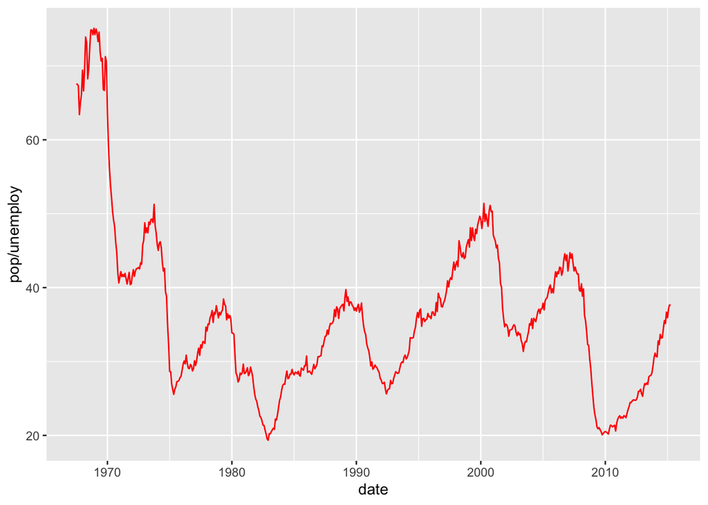

```r
# using geom_line make a graph that show the evolution of unemployment over the years x= date y=pop/unemployment
# name this graph time, make the line red and print the graph.

(time<-ggplot(data=economics) +
  geom_line(aes(x=date, y=pop/unemploy), color="red"))
```

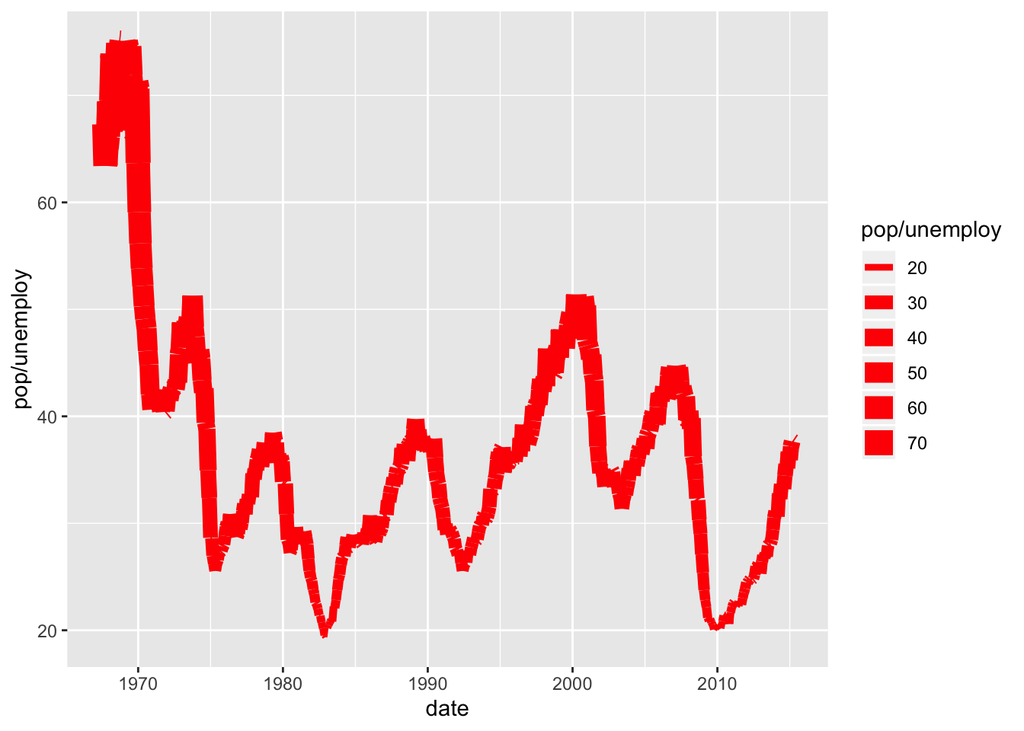

```r
#In the same graph change the size of the line by  pop/unemploy
(time<-ggplot(data=economics) +
  geom_line(aes(x=date, y=pop/unemploy, size=pop/unemploy),  color="red"))
```

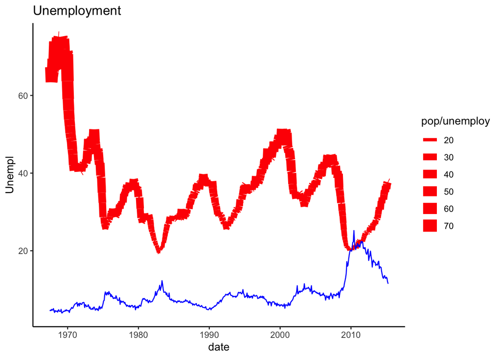

```r
# Add another line of that represents the median duration of unemployment, in weeks, evolution in time add a title "Unemployment" and label the y axis "Unempl"

time+ geom_line(aes(x=date, y=uempmed), color="blue")+
  labs(title="Unemployment")+ ylab("Unempl")+theme_classic()
```

### geom_area & stat_smooth()

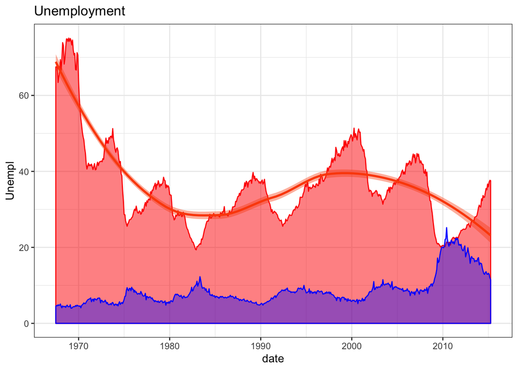

```r
# graphs
timearea<-ggplot(data=economics) +
  geom_area(aes(x=date, y=pop/unemploy), fill="red", col=2, alpha=0.5)

# add another area and use stat_smooth() to show a smooth trend line.
timearea +
  geom_area(aes(x=date, y=uempmed), fill=4, col=4, alpha=0.4)+ stat_smooth(aes(x=date, y=pop/unemploy),
  color = "#FC4E07", fill = "#FC4E07",
  method = "loess"
  )+
  labs(title="Unemployment")+ ylab("Unempl")+theme_bw()
```

# gganimate package

Part of this handout is based on [the gganimate website](https://gganimate.com/articles/gganimate.html)

## Transitions

With just a small addition you can convert a static plot into a complex animation. Transitions are functions that interpret the data in your graph in a way that ins distributed into a number of frames.

### Reaveal

Letting the data gradually appear with with `transition_reveal()`

```r
static<-ggplot(data=economics, aes(x=date, y=pop/unemploy)) +
  geom_line(color="red")
static +
  transition_reveal(date) #reveal by date
```

[output not shown]

```r
static +
  geom_point() +
  transition_reveal(date)
```

[output not shown]

### States

`transition_states()` specifically splits the data into subsets based on a variable in the data.

```r
college <- data.frame(read.csv("http://672258.youcanlearnit.net/college.csv") )
barstatic<-college %>%
  group_by(control, region) %>%
  summarize(average_tuition=round(mean(tuition), 0)) %>%
  ggplot(mapping=aes(x=region, y=average_tuition, fill=control, label=average_tuition)) +
  geom_col()+
  geom_text(size=4, fontface=2, color="yellow", position = position_stack(vjust = 0.5))+
  ylab("Average Tuition") + xlab("Region")+
  ggtitle("Average Tuition by Region and Type of School") +
  theme(plot.title = element_text(hjust = 0.5))
```

```r
barstatic + transition_states(region, wrap = FALSE) +
  shadow_mark()
```

[output not shown]

```r
barstatic + transition_states(control, wrap = TRUE)+
  shadow_mark()
```

[output not shown]

```r
barstatic + transition_states(control, wrap = FALSE)
```

[output not shown]

### Labelling, time, ease_aes()

An animated graphs like any visualization is only good if it conveys the information right. Providing the an indication as to what each frame or point in time refers to is important. The information about the each frame is created by gganimate and can be inserted in the labels option by embedding them in curly braces which are then evaluated and inserted into the argument string. See example

`transition_time()` transitions to differents states according to a time variable `ease_aes()` defines the velocity with which aesthetics change during an animation.

```r
ggplot(gapminder, aes(gdpPercap, lifeExp, size = pop, colour = country)) +
  geom_point(alpha = 0.7, show.legend = FALSE) +
  scale_colour_manual(values = country_colors) +
  scale_size(range = c(2, 12)) +
  scale_x_log10() +
  facet_wrap(~continent) +
  # Here comes the gganimate specific bits
  labs(title = 'Year: {frame_time}', x = 'GDP per capita', y = 'life expectancy') +
  transition_time(year) +
  ease_aes('linear') #
```

[output not shown]

**Packages used in this document**

Make sure you gave the package devtools, gganimate, gifski installed

`library(tidyverse)`

`library(gapminder)`

`library(knitr)`

`library(gtools)`

`library(gganimate)`

ECON320 R Programing Laboratory

Professor *Paloma Lopez de mesa Moyano*

*paloma.moyano@emory.edu*

Department of Economics

Emory University